# MECH481A6: Engineering Data Analysis in R

Chapter 11 Homework: Modeling

Daniel Pelphrey

15 November, 2023

# Chapter 11 Homework

This homework will give you experience with OLS linear models and testing their assumptions.

For this first problem set, we will examine issues of *collinearity among predictor variables* when fitting an OLS model with two variables. As you recall, assumption 3 from OLS regression requires there be no *collinearity* among predictor variables (the $X_i$’s) in a linear model. The reason is that the model struggles to assign the correct $\beta_i$ values to each predictor when they are strongly correlated.

## Question 1

Fit a series of three linear models on the `bodysize.csv` data frame using `lm()` with `height` as the dependent variable:  
1. Model 1: use `waist` as the independent predictor variable:  
- `formula = height ~ waist`  
2. Model 2: use `mass` as the independent predictor variable:  
- `formula = height ~ mass`  
3. Model 3: use `mass + waist` as a linear combination of predictor variables:  
- `formula = waist + mass`

Report the coefficients for each of these models. What happens to the sign and magnitude of the `mass` and `waist` coefficients when the two variables are included together? Contrast that with the coefficients when they are used alone.

Evaluate assumption 3 about whether there is collinearity among these variables. Do you trust the coefficients from model 3 after having seen the individual coefficients reported in models 1 and 2?

```
## # A tibble: 6 × 8
##    ...1    id  mass waist height gender   age sqrt_mass
##   <dbl> <dbl> <dbl> <dbl>  <dbl>  <dbl> <dbl>     <dbl>
## 1     1 93705  79.5 102.    158.      2    66      8.92
## 2     2 93706  66.3  79.3   176.      1    18      8.14
## 3     3 93708  53.5  88.2   150.      2    66      7.31
## 4     4 93709  88.8 113     151.      2    75      9.42
## 5     5 93711  62.1  86.6   171.      1    56      7.88
## 6     6 93712  58.9  72     173.      1    18      7.67
```

```
## (Intercept)       waist
## 155.4967199   0.1099283
```

```
## (Intercept)        mass
## 150.6109083   0.1909431
```

```
## (Intercept)       waist        mass
## 177.4604248  -0.6347416   0.6394358
```

## Question 2

Create a new variable in the `bodysize` data frame using `dplyr::mutate`. Call this variable `volume` and make it equal to $waist^2*height$. Use this new variable to predict `mass`.

Does this variable explain more of the variance in `mass` from the NHANES data? How do you know? (hint: there is both *process* and *quantitative* proof here)

[output not shown]

```
##
## Call:
## lm(formula = mass ~ volume, data = bodysize)
##
## Residuals:
##     Min      1Q  Median      3Q     Max
## -25.818  -5.217  -0.417   4.821  57.583
##
## Coefficients:
##              Estimate Std. Error t value Pr(>|t|)
## (Intercept) 2.546e+01  3.149e-01   80.86   <2e-16 ***
## volume      3.291e-05  1.711e-07  192.38   <2e-16 ***
## ---
## Signif. codes:  0 '***' 0.001 '**' 0.01 '*' 0.05 '.' 0.1 ' ' 1
##
## Residual standard error: 7.841 on 5173 degrees of freedom
##   (358 observations deleted due to missingness)
## Multiple R-squared:  0.8774, Adjusted R-squared:  0.8773
## F-statistic: 3.701e+04 on 1 and 5173 DF,  p-value: < 2.2e-16
```

Create a scatterplot of `mass` vs. `volume` to examine the fit. Draw a fit line using `geom_smooth()`.

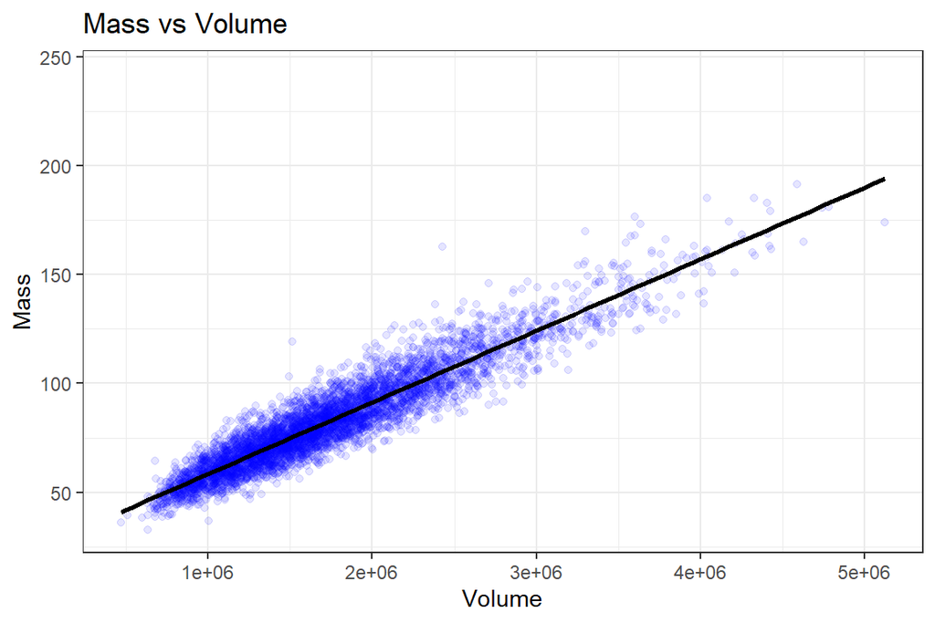

## Question 3

Load the `cal_aod.csv` data file and fit a linear model with `aeronet` as the independent variable and `AMOD` as the independent variable.

Evaluate model assumptions 4-7 from the coursebook. Are all these assumptions valid?

```
## [1] -2.351985e-18
```

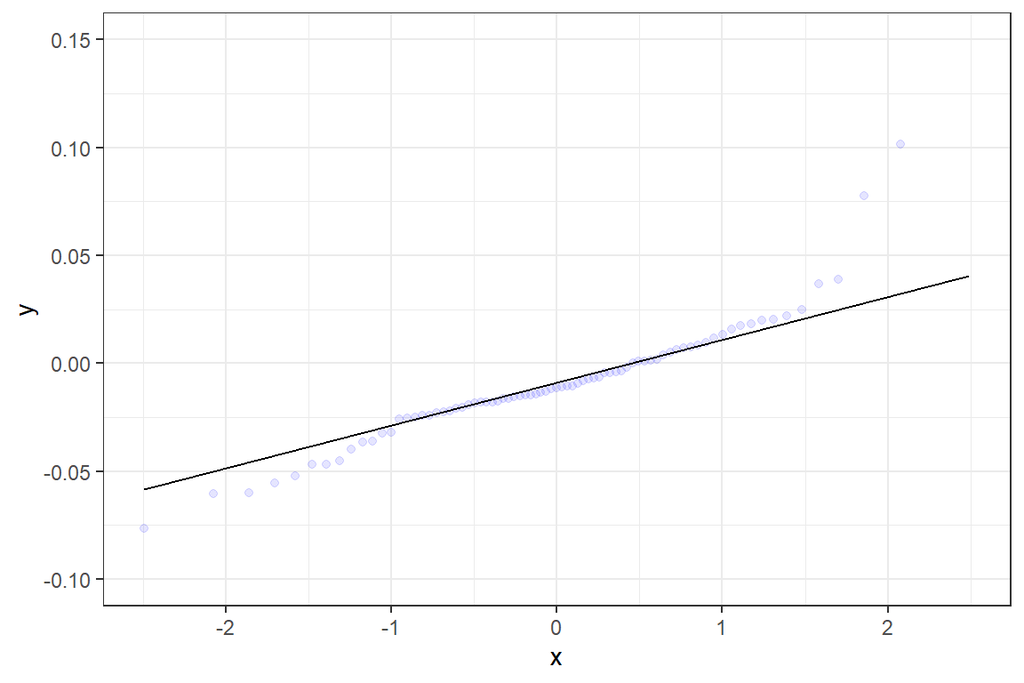

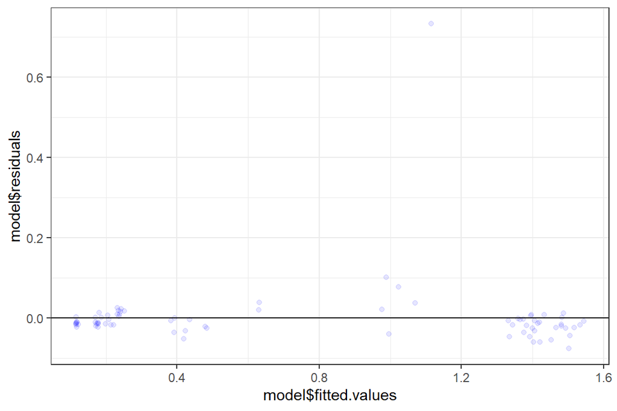

```
## [1] 9.119546e-20
```